# HW 4 SVM experiments

```python
import os, struct
import matplotlib.pyplot as plt
%matplotlib inline
import numpy as np
from array import array as pyarray
from numpy import append, array, int8, uint8, zeros
import sklearn as sk
from sklearn.svm import SVC
from sklearn.linear_model import LinearRegression
import time
from sklearn.preprocessing import PolynomialFeatures

def load_mnist(dataset="training", digits=None, path=None, asbytes=False, selection=None, return_labels=True, return_indices=False):
    """
    Loads MNIST files into a 3D numpy array.

    You have to download the data separately from [MNIST]_. It is recommended
    to set the environment variable ``MNIST`` to point to the folder where you
    put the data, so that you don't have to select path. On a Linux+bash setup,
    this is done by adding the following to your ``.bashrc``::

        export MNIST=/path/to/mnist

    Parameters
    ----------
    dataset : str
        Either "training" or "testing", depending on which dataset you want to
        load.
    digits : list
        Integer list of digits to load. The entire database is loaded if set to
        ``None``. Default is ``None``.
    path : str
        Path to your MNIST datafiles. The default is ``None``, which will try
        to take the path from your environment variable ``MNIST``. The data can
        be downloaded from http://yann.lecun.com/exdb/mnist/.
    asbytes : bool
        If True, returns data as ``numpy.uint8`` in [0, 255] as opposed to
        ``numpy.float64`` in [0.0, 1.0].
    selection : slice
        Using a `slice` object, specify what subset of the dataset to load. An
        example is ``slice(0, 20, 2)``, which would load every other digit
        until--but not including--the twentieth.
    return_labels : bool
        Specify whether or not labels should be returned. This is also a speed
        performance if digits are not specified, since then the labels file
        does not need to be read at all.
    return_indicies : bool
        Specify whether or not to return the MNIST indices that were fetched.
        This is valuable only if digits is specified, because in that case it
        can be valuable to know how far
        in the database it reached.

    Returns
    -------
    images : ndarray
        Image data of shape ``(N, rows, cols)``, where ``N`` is the number of images. If neither labels nor inices are returned, then this is returned directly, and not inside a 1-sized tuple.
    labels : ndarray
        Array of size ``N`` describing the labels. Returned only if ``return_labels`` is `True`, which is default.
    indices : ndarray
        The indices in the database that were returned.

    Examples
    --------
    Assuming that you have downloaded the MNIST database and set the
    environment variable ``$MNIST`` point to the folder, this will load all
    images and labels from the training set:

    >>> images, labels = ag.io.load_mnist('training') # doctest: +SKIP

    Load 100 sevens from the testing set:

    >>> sevens = ag.io.load_mnist('testing', digits=[7], selection=slice(0, 100), return_labels=False) # doctest: +SKIP

    """

    # The files are assumed to have these names and should be found in 'path'
    files = {
        'training': ('train-images-idx3-ubyte', 'train-labels-idx1-ubyte'),
        'testing': ('t10k-images-idx3-ubyte', 't10k-labels-idx1-ubyte'),
    }

    if path is None:
        try:
            path = os.environ['MNIST']
        except KeyError:
            raise ValueError("Unspecified path requires environment variable $MNIST to be set")

    try:
        images_fname = os.path.join(path, files[dataset][0])
        labels_fname = os.path.join(path, files[dataset][1])
    except KeyError:
        raise ValueError("Data set must be 'testing' or 'training'")

    # We can skip the labels file only if digits aren't specified and labels aren't asked for
    if return_labels or digits is not None:
        flbl = open(labels_fname, 'rb')
        magic_nr, size = struct.unpack(">II", flbl.read(8))
        labels_raw = pyarray("b", flbl.read())
        flbl.close()

    fimg = open(images_fname, 'rb')
    magic_nr, size, rows, cols = struct.unpack(">IIII", fimg.read(16))
    images_raw = pyarray("B", fimg.read())
    fimg.close()

    if digits:
        indices = [k for k in range(size) if labels_raw[k] in digits]
    else:
        indices = range(size)

    if selection:
        indices = indices[selection]
    N = len(indices)

    images = zeros((N, rows, cols), dtype=uint8)

    if return_labels:
        labels = zeros((N), dtype=int8)
    for i, index in enumerate(indices):
        images[i] = array(images_raw[ indices[i]*rows*cols : (indices[i]+1)*rows*cols ]).reshape((rows, cols))
        if return_labels:
            labels[i] = labels_raw[indices[i]]

    if not asbytes:
        images = images.astype(float)/255.0

    ret = (images,)
    if return_labels:
        ret += (labels,)
    if return_indices:
        ret += (indices,)
    if len(ret) == 1:
        return ret[0] # Don't return a tuple of one
    else:
        return ret
```

```python
path = r"C:\Users\avido\Desktop\NU Coursework\CS 349 - Machine Learning\homeworks\hw4-SVM-Flishworks\data"

train_images, train_labels = load_mnist(dataset="training", digits=None, path=path, asbytes=False, selection=None, return_labels=True, return_indices=False)
test_images, test_labels = load_mnist(dataset="testing", digits=None, path=path, asbytes=False, selection=None, return_labels=True, return_indices=False)
```

1. How many of each number are there?

```python
hist = np.histogram(test_labels, bins=10)
hist
```

```
(array([ 980, 1135, 1032, 1010,  982,  892,  958, 1028,  974, 1009],
       dtype=int64),
 array([0. , 0.9, 1.8, 2.7, 3.6, 4.5, 5.4, 6.3, 7.2, 8.1, 9. ]))
```

1. Find some funny lookin numbers

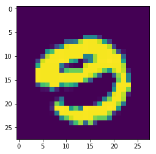

```python
plt.imshow(train_images[train_labels == 9][2300])
```

1. Estimate training time

```python
kernal_type = 'poly' #rbf' #'poly'#'linear'
ns = [9000]#, 1000, 2000, 3160]

y=[]
for i, n in enumerate(ns):
    now = time.time()
    train_images_flat = train_images.reshape(60000,28**2)
    clf = SVC(gamma='auto', kernel= kernal_type)
    clf.fit(train_images_flat[0:n], train_labels[0:n])
    timer = time.time() - now
    print("n = ", n, "time = ", timer, " seconds")
    y.append(timer) #for linear regression in next problem
```

```
n =  9000 time =  145.0514042377472  seconds
```

```python
train_images_flat.shape
```

```
(60000, 784)
```

```python
kernal_type = 'linear'
n = 500
train_subset, test_subset, train_labels_subset, test_labels_subset = get_sample(n, n)
train_images_flat = train_images.reshape(60000,28**2)

now = time.time()
clf = SVC(C = 1, kernel = kernal_type, gamma='auto')
#clf.fit(train_subset,  train_labels_subset)
clf.fit(train_images_flat[0:n], train_labels[0:n])
#predicted = clf.predict(test_subset)
timer = time.time() - now
print("elapsed time: ", timer, " seconds")#/60, " minutes")
```

```
elapsed time:  0.14905571937561035  seconds
```

1. find equation for time based on number of samples

```python
x=np.array(ns).reshape(-1, 1)
x = x**3
reg = LinearRegression(fit_intercept=True).fit(x, y)
print("T=",reg.intercept_,"+",reg.coef_[0],"*N^3 ")
reg.predict(np.array([500**3]).reshape(-1, 1))
```

```
T= 2.669461113099189 + -8.324713158589488e-10 *N^3
```

```
array([2.5654022])
```

```python
poly = PolynomialFeatures(3)
x=poly.fit_transform(np.array(ns).reshape(-1, 1))
reg = LinearRegression(fit_intercept=False).fit(x, y)
print("T=",reg.coef_[0],"+",reg.coef_[1],"*N + ",reg.coef_[2],"*N^2 + ",reg.coef_[3],"*N^3 ")
reg.predict(np.array([1,500,500**2,500**3]).reshape(1, -1))
```

```
T= 0.537045813271694 + -0.0017531132039627063 *N +  3.244192454931724e-06 *N^2 +  -3.9536263090876016e-10 *N^3
```

```
array([0.422117])
```

Finding the best hyperparameters

```python
def get_sample(train_N, test_N):
    train_images_flat = train_images.reshape(60000,28**2)
    test_images_flat = test_images.reshape(10000,28**2)
    train_subset = []
    test_subset = []
    train_labels_subset = []
    test_labels_subset = []
    for digit in range(10):
        train_images_flat_digit = train_images_flat[train_labels == digit]
        test_images_flat_digit = test_images_flat[test_labels == digit]
        train_subset.append(train_images_flat_digit[np.random.choice(train_images_flat_digit.shape[0], size= int(train_N/10), replace=False), :])
        test_subset.append(test_images_flat_digit[np.random.choice(test_images_flat_digit.shape[0], size= int(test_N/10), replace=False), :])
        train_labels_subset.append(np.ones(int(train_N/10))*digit)
        test_labels_subset.append(np.ones(int(test_N/10))*digit)

    train_subset = np.array(train_subset).reshape(train_N, 784, order='C')
    test_subset = np.array(test_subset).reshape(test_N, 784, order='C')
    train_labels_subset = np.array(train_labels_subset).reshape(train_N)
    test_labels_subset = np.array(test_labels_subset).reshape(test_N)
    return train_subset, test_subset, train_labels_subset, test_labels_subset

def get_error(actual, predicted):
    return np.sum(actual != predicted)/len(actual)
```

```python
kernel_type = ['linear', 'poly', 'rbf']
training_N = 9000
testing_N = 1500
cost = [0.1, 1, 10]
now = time.time()
errors = []
for c in cost:
    #select training and testing subset
    for kernal in kernel_type:
        for i in range(20): #repeat 20 times
            train_subset, test_subset, train_labels_subset, test_labels_subset = get_sample(training_N, testing_N)
            clf = SVC(C = c, kernel = kernal, gamma='auto')
            clf.fit(train_subset,  train_labels_subset)
            predicted = clf.predict(test_subset)
            errors.append([kernal, c, get_error(test_labels_subset, predicted)])

timer = time.time() - now
print("elapsed time: ", timer/60, " minutes")
errors
```

```
elapsed time:  205.41856169700623  minutes
```

[output not shown]

[output cut: 125 more lines]

[output not shown]

1. Create a table with 3 rows (1 kernel per row) and 3 columns (the 3 slack settings). Rows and columns should be clearly labeled. For each condition (combination of slack and kernel), show the following 3 values: the testing error measure e, the standard deviation of the error std and the number of trials n, written in the format: e(std),n.

```python
kernel_type = 'linear'
cost = .1
e2 = errors[errors[:,0] == kernel_type]
e2[e2[:,1].astype(float) == cost][:,2].astype(float)
```

```
array([0.06666667, 0.06933333, 0.07      , 0.07066667, 0.06266667,
       0.06866667, 0.07266667, 0.06266667, 0.06133333, 0.06866667,
       0.06666667, 0.07      , 0.07466667, 0.086     , 0.07333333,
       0.07266667, 0.07066667, 0.076     , 0.084     , 0.07      ])
```

```python
kernel_type = ['linear', 'poly', 'rbf']
cost = [0.1, 1, 10]

print(cost)
for kernel in kernel_type:
    #row_text = kernel,","
    print(kernel)
    for c in cost:
        print(c)
        e2 = errors[errors[:,0] == kernel] #get just the kernel
        e2 = e2[e2[:,1].astype(float) == c][:,2].astype(float) #get just the cost
        mean = round(np.mean(e2),3)
        sd = round(np.std(e2),3)
        n = len(e2)
        print(mean,"(",sd,"),",n)
        #row_text = row_text, mean,"(",sd,"),",len(errors[errors[:,0] == kernel][:,2])
    #print(row_text)
```

```
[0.1, 1, 10]
linear
0.1
0.071 ( 0.006 ), 20
1
0.084 ( 0.009 ), 20
10
0.086 ( 0.006 ), 20
poly
0.1
0.804 ( 0.014 ), 20
1
0.788 ( 0.011 ), 20
10
0.303 ( 0.013 ), 20
rbf
0.1
0.13 ( 0.007 ), 20
1
0.08 ( 0.006 ), 20
10
0.06 ( 0.004 ), 20
```

1. Make a boxplot graph that plots testing error (vertical) as a function of the slack C (horizontal). Use average results across all kernels. Indicate n on your plot, where n is the number trials per boxplot. Don't forget to label your dimensions.

```
Text(0.5,1,'N=60')
```

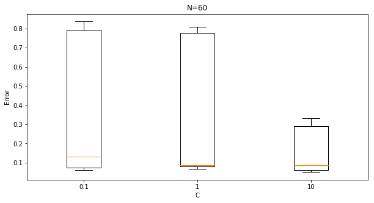

```python
cost = [0.1, 1, 10]
data = []
for c in cost:
    e2 = errors[errors[:,1].astype(float) == c][:,2].astype(float) #get just the cost
    data.append(e2)

# Create a figure instance
fig = plt.figure(1, figsize=(10, 5))
# Create an axes instance
ax = fig.add_subplot(111)
# Create the boxplot
bp = ax.boxplot(data)
ax.set_xticklabels(cost)
plt.ylabel('Error')
plt.xlabel('C')
plt.title('N=60')
```

```
Text(0.5,1,'N=60')
```

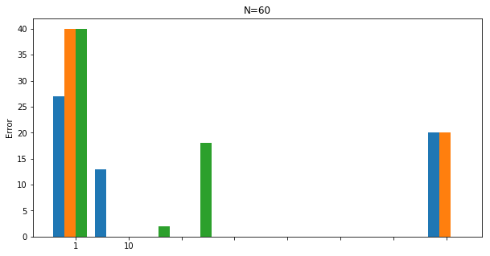

```python
cost = [0.1, 1, 10]
data = []
for c in cost:
    e2 = errors[errors[:,1].astype(float) == c][:,2].astype(float) #get just the cost
    data.append(e2)

# Create a figure instance
fig = plt.figure(1, figsize=(10, 5))
# Create an axes instance
ax = fig.add_subplot(111)
# Create the boxplot
bp = ax.hist(data)
ax.set_xticklabels(cost)
plt.ylabel('Error')
plt.title('N=60')
```